# Filter genotypes, wecare feb2016

Alexey Larionov

started: 01Mar2016 last updated: 12May2016

# Notes

It was discussed with DC whether to filter cases by call rate per case. There was ~3 cases with low coverage (<20) and low call rates (<50%). We desided to keep such cases because their retained genotypes still passed all filters.

Instead of setting the thresholds by the proportions of reads (as done in this script), it is possible to set thresholds by probability of the observed reads. This could be dome using pbinom(count of minor reads, sum of reads, 0.5). The used proportion thresholds correspond to 1-5%, depending on total reads count.

Thresholds for min DP and GQ were set to 10 and 20 because they are commonly used (e.g. see Carson BMC Bioinformatics 2014 15:125).

A small number of genotypes (~0.01%) was covered too high to be true (up to 1-2k coverage). These are obvious mistakes, and they have been removed too. Arbitrary the threshold for max DP was set to 500 (~10 x Average Coverage).

# start_section

```r
# Time stamp
Sys.time()
```

```
## [1] "2016-05-13 15:32:21 BST"
```

```r
# Clean-up
rm(list=ls())
graphics.off()

# Set root working folder
library(knitr)
opts_knit$set(root.dir = "/scratch/medgen/scripts/rscripts_05.16")
#setwd("/scratch/medgen/scripts/rscripts_05.16")

#opts_knit$set(root.dir = "C:\\Users\\larion01\\Documents\\GitHub\\R1")
#setwd("C:\\Users\\larion01\\Documents\\GitHub\\R1")
```

# filtering_settings

```r
# Set thresholds for cumulative reads depth and genotype quality
min.dp <- 10
max.dp <- 500
min.gq <- 20

# Minimal call rate per variant
min.call.rate <- 0.8

# Set theresholds for fraction of reads with minor allele (frma)
max.frma.hom <- 0.05 # Max frma for homozigous calls
min.frma.het <- 0.35 # Min frma for heterozigous calls
```

# load_and_check_data

```r
load(file="data/s02_filter_variants_feb2016.RData")
ls()
```

```
##  [1] "alt.pf.mx"       "covar.df"        "demographics.df"
##  [4] "dp.pf.df"        "gq.pf.df"        "gt.pf.df"
##  [7] "max.dp"          "max.frma.hom"    "min.call.rate"
## [10] "min.dp"          "min.frma.het"    "min.gq"
## [13] "ref.pf.mx"       "samples.df"      "vv.pf.df"
```

```r
dim(covar.df)
```

```
## [1] 498  34
```

```r
str(covar.df)
```

```
## 'data.frame':    498 obs. of  34 variables:
##  $ Subject_ID      : int  200054 200491 200565 200698 200958 201046 201558 201921 202026 202236 ...
##  $ setno           : int  382125 204356 360683 226881 357431 374980 201558 201921 213991 385058 ...
##  $ cc              : int  0 0 0 0 0 0 1 1 0 0 ...
##  $ chemo           : int  1 1 0 0 1 1 1 1 1 1 ...
##  $ hormone         : int  0 1 1 0 1 0 0 1 1 0 ...
##  $ chemo_hormone   : Factor w/ 5 levels "","both","chem",..: 3 2 4 5 2 3 3 2 2 3 ...
##  $ chemo_self_mra  : int  1 1 0 0 1 1 1 1 1 1 ...
##  $ hormone_self_mra: int  0 1 1 0 1 0 0 1 1 0 ...
##  $ treatment       : int  1 1 1 0 1 1 1 1 1 1 ...
##  $ ID              : int  2 6 7 9 11 12 16 22 24 26 ...
##  $ labid           : Factor w/ 498 levels "id200054","id200491",..: 1 2 3 4 5 6 7 8 9 10 ...
##  $ status          : int  0 0 0 0 0 0 1 1 0 0 ...
##  $ status2         : int  0 0 0 0 0 0 1 1 0 0 ...
##  $ offset          : num  6.41 5.82 5.61 4.03 4.77 ...
```

[output cut: 20 more lines]

```r
covar.df[1:5,1:5]
```

```
##   Subject_ID  setno cc chemo hormone
## 1     200054 382125  0     1       0
## 2     200491 204356  0     1       1
## 3     200565 360683  0     0       1
## 4     200698 226881  0     0       0
## 5     200958 357431  0     1       1
```

```r
dim(demographics.df)
```

```
## [1] 505  91
```

```r
str(demographics.df)
```

```
## 'data.frame':    505 obs. of  91 variables:
##  $ Subject_ID            : Factor w/ 503 levels "200054","200491",..: 1 2 3 4 5 6 7 8 9 10 ...
##  $ ID.x                  : num  2 6 7 9 11 12 NA NA 24 26 ...
##  $ labid.x               : Factor w/ 498 levels "15582015","19212019",..: 6 7 8 9 10 11 NA NA 12 13 ...
##  $ Eigen_1.x             : num  -0.0079 -0.01062 -0.00539 -0.00906 -0.01094 ...
##  $ Eigen_2.x             : num  0.0055 0.00414 0.00302 0.00301 0.0023 ...
##  $ Eigen_3.x             : num  -0.02171 0.01254 0.00368 -0.00655 -0.01389 ...
##  $ Eigen_4.x             : num  0.00356 -0.00787 -0.01496 -0.01256 -0.00501 ...
##  $ Eigen_5.x             : num  0.00135 -0.0291 0.00391 0.01357 -0.00526 ...
##  $ Phase                 : num  1 1 1 1 1 1 NA NA 1 1 ...
##  $ setno.x               : num  382125 204356 360683 226881 357431 ...
##  $ cc.x                  : int  0 0 0 0 0 0 NA NA 0 0 ...
##  $ rstime                : num  7.42 9.75 6.09 6.25 9.34 7 NA NA 6.09 8.66 ...
##  $ registry.x            : Factor w/ 7 levels "","de","IA","IR",..: 2 4 4 7 7 5 NA NA 3 2 ...
##  $ race.x                : num  0 0 0 0 0 0 NA NA 0 0 ...
```

[output cut: 77 more lines]

```r
demographics.df[1:5,1:5]
```

```
##   Subject_ID ID.x  labid.x    Eigen_1.x   Eigen_2.x
## 1     200054    2 id200054 -0.007897666 0.005498053
## 2     200491    6 id200491 -0.010615326 0.004141289
## 3     200565    7 id200565 -0.005393813 0.003017045
## 4     200698    9 id200698 -0.009061714 0.003010147
## 5     200958   11 id200958 -0.010936549 0.002295868
```

```r
dim(samples.df)
```

```
## [1] 512   4
```

```r
str(samples.df)
```

```
## 'data.frame':    512 obs. of  4 variables:
##  $ wes_id   : Factor w/ 512 levels "P1_A01","P1_A02",..: 1 2 3 4 5 6 7 8 9 10 ...
##  $ gwas_id  : Factor w/ 510 levels "id200054","id200491",..: 14 405 315 264 67 121 326 251 281 141 ...
##  $ merged_id: Factor w/ 512 levels "P1_A01_id203568",..: 1 2 3 4 5 6 7 8 9 10 ...
##  $ filter   : Factor w/ 5 levels "duplicate","low_concordance",..: 5 5 5 5 5 5 5 5 5 5 ...
```

```r
samples.df[1:5,]
```

```
##   wes_id  gwas_id       merged_id filter
## 1 P1_A01 id203568 P1_A01_id203568   pass
## 2 P1_A02 id357807 P1_A02_id357807   pass
## 3 P1_A03 id325472 P1_A03_id325472   pass
## 4 P1_A04 id304354 P1_A04_id304354   pass
## 5 P1_A05 id222648 P1_A05_id222648   pass
```

```r
dim(vv.pf.df)
```

```
## [1] 280782     45
```

```r
str(vv.pf.df)
```

```
## 'data.frame':    280782 obs. of  45 variables:
##  $ MultiAllelic           : logi  NA NA NA NA NA NA ...
##  $ NDA                    : int  1 1 1 1 1 1 2 1 1 1 ...
##  $ TYPE                   : Factor w/ 2 levels "INDEL","SNP": 1 2 2 2 2 2 2 1 2 2 ...
##  $ CHROM                  : Factor w/ 25 levels "1","10","11",..: 1 1 1 1 1 1 1 1 1 1 ...
##  $ POS                    : int  664486 865628 865694 871173 871215 871230 871271 874778 878664 880461 ...
##  $ REF                    : Factor w/ 9189 levels "A","AAAAAAAAAAAAAAAAAAAAAAAAAAAAAAAAAAAAAAAAGAATAAATAAAAT",..: 7023 4792 2878 2878 2878 2878 2878 5448 4792 2878 ...
##  $ ALT                    : Factor w/ 4394 levels "A","AAAAAAAAAAAAAAAC",..: 3321 1 3321 1 2230 3321 3321 2230 1 3321 ...
##  $ QUAL                   : num  35230 602 997 450 1474 ...
##  $ DP                     : int  48969 11402 5556 9169 11112 10325 6499 10570 9383 18393 ...
##  $ VQSLOD                 : num  1.61 17.26 18.24 17.34 17.72 ...
##  $ FILTER                 : Factor w/ 46 levels "INDEL_DP_LESS_THAN_5120.0",..: 35 35 35 35 35 35 35 35 35 35 ...
##  $ AC                     : int  53 3 4 1 4 1 1 51 1 1 ...
##  $ AF                     : num  0.052 0.00299 0.00439 0.00101 0.00394 ...
##  $ AN                     : int  1024 1004 912 992 1016 1010 920 998 1018 1024 ...
```

[output cut: 31 more lines]

```r
vv.pf.df[1:5,1:5]
```

```
##              MultiAllelic NDA  TYPE CHROM    POS
## var000000060           NA   1 INDEL     1 664486
## var000000107           NA   1   SNP     1 865628
## var000000109           NA   1   SNP     1 865694
## var000000117           NA   1   SNP     1 871173
## var000000118           NA   1   SNP     1 871215
```

```r
dim(gt.pf.df)
```

```
## [1] 280782    512
```

```r
str(gt.pf.df, list.len=5)
```

```
## 'data.frame':    280782 obs. of  512 variables:
##  $ P1_A01.GT         : int  0 0 0 0 0 0 0 0 0 0 ...
##  $ P1_A02.GT         : int  1 NA NA 0 0 0 0 0 0 0 ...
##  $ P1_A03.GT         : int  0 0 0 0 0 0 0 0 0 0 ...
##  $ P1_A04.GT         : int  0 0 0 0 0 0 0 0 0 0 ...
##  $ P1_A05.GT         : int  0 0 0 0 0 0 0 0 0 0 ...
##   [list output truncated]
```

```r
gt.pf.df[1:5,1:5]
```

```
##              P1_A01.GT P1_A02.GT P1_A03.GT P1_A04.GT P1_A05.GT
## var000000060         0         1         0         0         0
## var000000107         0        NA         0         0         0
## var000000109         0        NA         0         0         0
## var000000117         0         0         0         0         0
## var000000118         0         0         0         0         0
```

```r
dim(gq.pf.df)
```

```
## [1] 280782    512
```

```r
str(gq.pf.df, list.len=5)
```

```
## 'data.frame':    280782 obs. of  512 variables:
##  $ P1_A01.GQ         : int  99 51 3 24 39 36 18 39 36 99 ...
##  $ P1_A02.GQ         : int  99 NA NA 21 24 18 3 6 18 60 ...
##  $ P1_A03.GQ         : int  99 3 6 12 18 15 3 12 33 84 ...
##  $ P1_A04.GQ         : int  99 63 48 27 84 75 39 75 60 99 ...
##  $ P1_A05.GQ         : int  99 15 9 6 15 12 12 21 30 99 ...
##   [list output truncated]
```

```r
gq.pf.df[1:5,1:5]
```

```
##              P1_A01.GQ P1_A02.GQ P1_A03.GQ P1_A04.GQ P1_A05.GQ
## var000000060        99        99        99        99        99
## var000000107        51        NA         3        63        15
## var000000109         3        NA         6        48         9
## var000000117        24        21        12        27         6
## var000000118        39        24        18        84        15
```

```r
dim(dp.pf.df)
```

```
## [1] 280782    512
```

```r
str(dp.pf.df, list.len=5)
```

```
## 'data.frame':    280782 obs. of  512 variables:
##  $ P1_A01.DP         : int  47 18 3 8 13 12 7 15 19 35 ...
##  $ P1_A02.DP         : int  151 0 0 7 8 6 1 4 8 20 ...
##  $ P1_A03.DP         : int  34 1 2 4 7 6 1 4 12 28 ...
##  $ P1_A04.DP         : int  53 21 17 10 28 25 17 29 22 40 ...
##  $ P1_A05.DP         : int  41 5 3 2 5 4 4 9 10 36 ...
##   [list output truncated]
```

```r
dp.pf.df[1:5,1:5]
```

```
##              P1_A01.DP P1_A02.DP P1_A03.DP P1_A04.DP P1_A05.DP
## var000000060        47       151        34        53        41
## var000000107        18         0         1        21         5
## var000000109         3         0         2        17         3
## var000000117         8         7         4        10         2
## var000000118        13         8         7        28         5
```

```r
dim(ref.pf.mx)
```

```
## [1] 280782    512
```

```r
class(ref.pf.mx)
```

```
## [1] "matrix"
```

```r
ref.pf.mx[1:15,1:5]
```

```
##              P1_A01.AD P1_A02.AD P1_A03.AD P1_A04.AD P1_A05.AD
## var000000060 "47"      "133"     "34"      "53"      "41"
## var000000107 "18"      "0"       "1"       "21"      "5"
## var000000109 "3"       "0"       "2"       "17"      "3"
## var000000117 "8"       "7"       "4"       "10"      "2"
## var000000118 "13"      "8"       "7"       "28"      "5"
## var000000119 "12"      "6"       "6"       "25"      "4"
## var000000120 "7"       "1"       "1"       "17"      "4"
## var000000124 "15"      "4"       "4"       "29"      "9"
## var000000140 "19"      "8"       "12"      "22"      "10"
## var000000157 "35"      "20"      "28"      "40"      "36"
## var000000158 "37"      "24"      "31"      "40"      "36"
## var000000159 "20"      "18"      "12"      "37"      "16"
## var000000163 "0"       "3"       "1"       "31"      "0"
## var000000169 "33"      "10"      "19"      "37"      "13"
## var000000170 "32"      "6"       "16"      "37"      "19"
```

```r
dim(alt.pf.mx)
```

```
## [1] 280782    512
```

```r
class(alt.pf.mx)
```

```
## [1] "matrix"
```

```r
alt.pf.mx[1:15,1:5]
```

```
##              P1_A01.AD P1_A02.AD P1_A03.AD P1_A04.AD P1_A05.AD
## var000000060 "0"       "18"      "0"       "0"       "0"
## var000000107 "0"       "0"       "0"       "0"       "0"
## var000000109 "0"       "0"       "0"       "0"       "0"
## var000000117 "0"       "0"       "0"       "0"       "0"
## var000000118 "0"       "0"       "0"       "0"       "0"
## var000000119 "0"       "0"       "0"       "0"       "0"
## var000000120 "0"       "0"       "0"       "0"       "0"
## var000000124 "0"       "0"       "0"       "0"       "0"
## var000000140 "0"       "0"       "0"       "0"       "0"
## var000000157 "0"       "0"       "0"       "0"       "0"
## var000000158 "0"       "0"       "0"       "0"       "0"
## var000000159 "0"       "0"       "0"       "0"       "0"
## var000000163 "27"      "2"       "7"       "20"      "7"
## var000000169 "0"       "0"       "0"       "0"       "0"
## var000000170 "0"       "0"       "0"       "0"       "0"
```

```r
# Check consistence of rownames
sum(rownames(gt.pf.df) != rownames(vv.pf.df), na.rm=TRUE)
```

```
## [1] 0
```

```r
sum(rownames(gt.pf.df) != rownames(gq.pf.df), na.rm=TRUE)
```

```
## [1] 0
```

```r
sum(rownames(gt.pf.df) != rownames(dp.pf.df), na.rm=TRUE)
```

```
## [1] 0
```

```r
sum(rownames(gt.pf.df) != rownames(ref.pf.mx), na.rm=TRUE)
```

```
## [1] 0
```

```r
sum(rownames(gt.pf.df) != rownames(alt.pf.mx), na.rm=TRUE)
```

```
## [1] 0
```

```r
# Check consistence of colnames (sub(".DP","") may be used instead)
sum(substr(colnames(gt.pf.df),0,6) != substr(colnames(gq.pf.df),0,6), na.rm=TRUE)
```

```
## [1] 0
```

```r
sum(substr(colnames(gt.pf.df),0,6) != substr(colnames(dp.pf.df),0,6), na.rm=TRUE)
```

```
## [1] 0
```

```r
sum(substr(colnames(gt.pf.df),0,6) != substr(colnames(ref.pf.mx),0,6), na.rm=TRUE)
```

```
## [1] 0
```

```r
sum(substr(colnames(gt.pf.df),0,6) != substr(colnames(alt.pf.mx),0,6), na.rm=TRUE)
```

```
## [1] 0
```

# convert_data_frames_to_matrices

```r
gt.mx <- as.matrix(gt.pf.df)
gq.mx <- as.matrix(gq.pf.df)
dp.mx <- as.matrix(dp.pf.df)
rm(gt.pf.df, gq.pf.df, dp.pf.df)

dim(gt.mx)
```

```
## [1] 280782    512
```

```r
class(gt.mx)
```

```
## [1] "matrix"
```

```r
gt.mx[1:5,1:5]
```

```
##              P1_A01.GT P1_A02.GT P1_A03.GT P1_A04.GT P1_A05.GT
## var000000060         0         1         0         0         0
## var000000107         0        NA         0         0         0
## var000000109         0        NA         0         0         0
## var000000117         0         0         0         0         0
## var000000118         0         0         0         0         0
```

```r
dim(gq.mx)
```

```
## [1] 280782    512
```

```r
class(gq.mx)
```

```
## [1] "matrix"
```

```r
gq.mx[1:5,1:5]
```

```
##              P1_A01.GQ P1_A02.GQ P1_A03.GQ P1_A04.GQ P1_A05.GQ
## var000000060        99        99        99        99        99
## var000000107        51        NA         3        63        15
## var000000109         3        NA         6        48         9
## var000000117        24        21        12        27         6
## var000000118        39        24        18        84        15
```

```r
dim(dp.mx)
```

```
## [1] 280782    512
```

```r
class(dp.mx)
```

```
## [1] "matrix"
```

```r
dp.mx[1:5,1:5]
```

```
##              P1_A01.DP P1_A02.DP P1_A03.DP P1_A04.DP P1_A05.DP
## var000000060        47       151        34        53        41
## var000000107        18         0         1        21         5
## var000000109         3         0         2        17         3
## var000000117         8         7         4        10         2
## var000000118        13         8         7        28         5
```

# convert_ref_alt_matrices_to_numeric

```r
ref.alt.rownames <- rownames(ref.pf.mx)
ref.alt.colnames <- colnames(ref.pf.mx)

ref.mx <- matrix(as.numeric(ref.pf.mx), nrow=nrow(ref.pf.mx))
rownames(ref.mx) <- ref.alt.rownames
colnames(ref.mx) <- ref.alt.colnames

dim(ref.mx)
```

```
## [1] 280782    512
```

```r
class(ref.mx)
```

```
## [1] "matrix"
```

```r
ref.mx[1:15,1:5]
```

```
##              P1_A01.AD P1_A02.AD P1_A03.AD P1_A04.AD P1_A05.AD
## var000000060        47       133        34        53        41
## var000000107        18         0         1        21         5
## var000000109         3         0         2        17         3
## var000000117         8         7         4        10         2
## var000000118        13         8         7        28         5
## var000000119        12         6         6        25         4
## var000000120         7         1         1        17         4
## var000000124        15         4         4        29         9
## var000000140        19         8        12        22        10
## var000000157        35        20        28        40        36
## var000000158        37        24        31        40        36
## var000000159        20        18        12        37        16
## var000000163         0         3         1        31         0
## var000000169        33        10        19        37        13
## var000000170        32         6        16        37        19
```

```r
alt.mx <- matrix(as.numeric(alt.pf.mx), nrow=nrow(alt.pf.mx))
rownames(alt.mx) <- ref.alt.rownames
colnames(alt.mx) <- ref.alt.colnames

dim(alt.mx)
```

```
## [1] 280782    512
```

```r
class(alt.mx)
```

```
## [1] "matrix"
```

```r
alt.mx[1:15,1:5]
```

```
##              P1_A01.AD P1_A02.AD P1_A03.AD P1_A04.AD P1_A05.AD
## var000000060         0        18         0         0         0
## var000000107         0         0         0         0         0
## var000000109         0         0         0         0         0
## var000000117         0         0         0         0         0
## var000000118         0         0         0         0         0
## var000000119         0         0         0         0         0
## var000000120         0         0         0         0         0
## var000000124         0         0         0         0         0
## var000000140         0         0         0         0         0
## var000000157         0         0         0         0         0
## var000000158         0         0         0         0         0
## var000000159         0         0         0         0         0
## var000000163        27         2         7        20         7
## var000000169         0         0         0         0         0
## var000000170         0         0         0         0         0
```

```r
rm(ref.alt.rownames, ref.alt.colnames, ref.pf.mx, alt.pf.mx)
```

# histograms_before_filtering

```r
# Total num of NAs before genotype filtering
sum(is.na(gt.mx))/(dim(gt.mx)[1]*dim(gt.mx)[2]) # <1%
```

```
## [1] 0.006348307
```

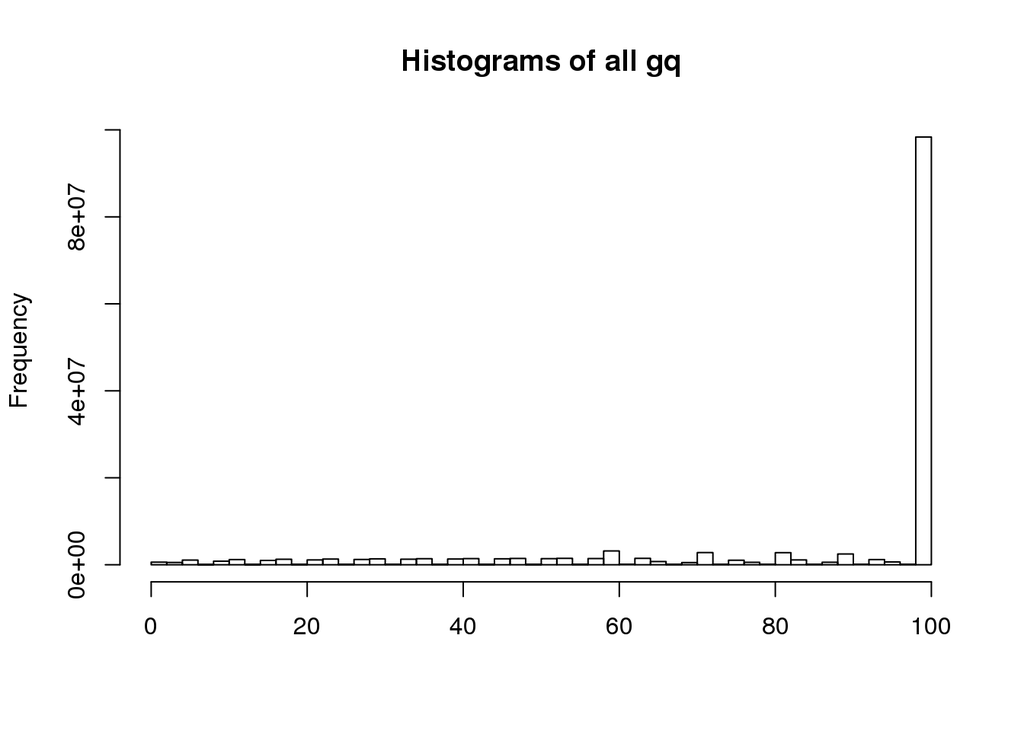

```r
# Histograms of all gq and dp
hist(gq.mx, breaks=50, main="Histograms of all gq", xlab=NULL)
```

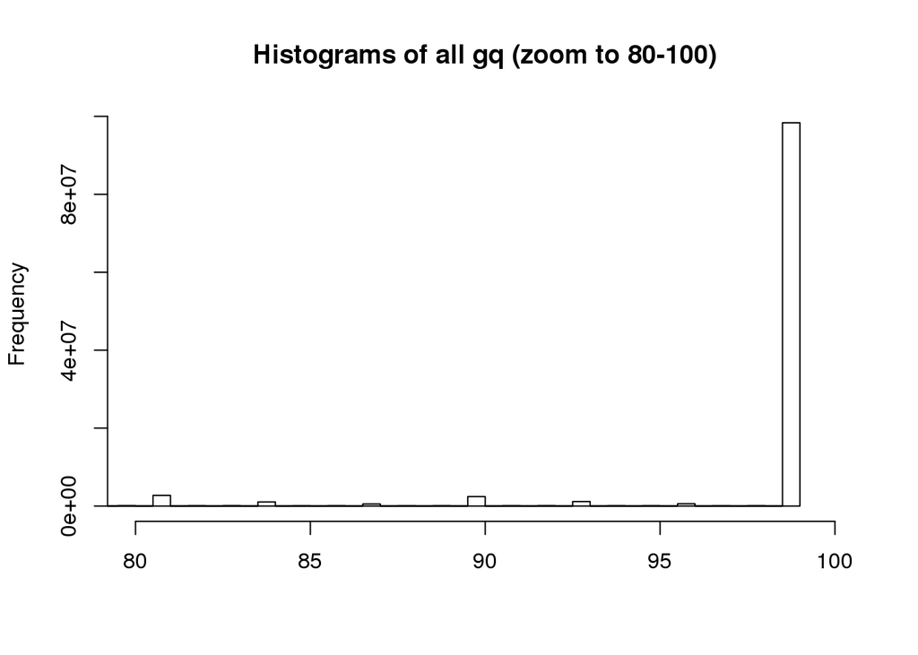

```r
hist(gq.mx, breaks=250, xlim=c(80,100), main="Histograms of all gq (zoom to 80-100)", xlab=NULL)
```

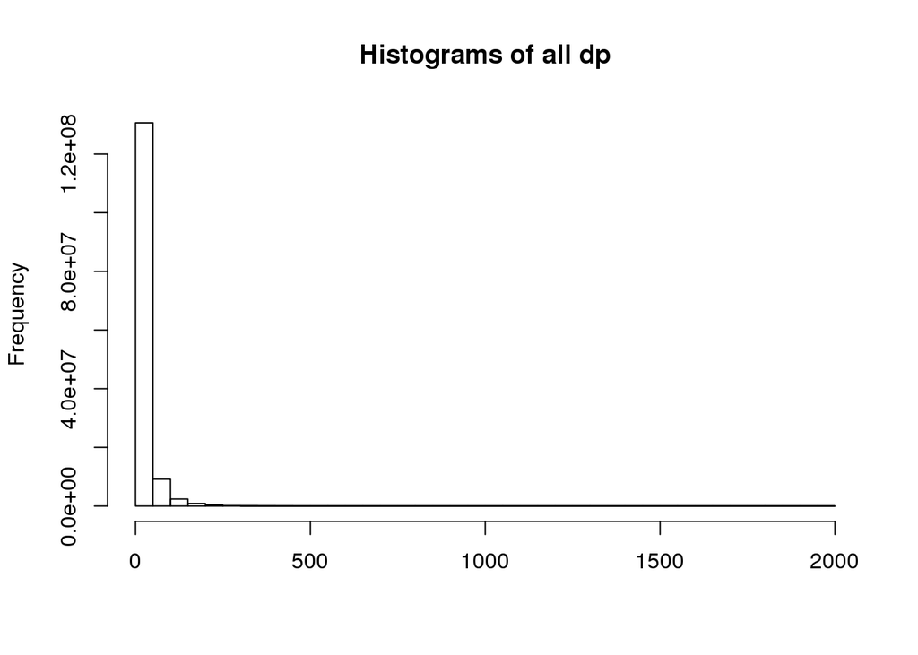

```r
hist(dp.mx, breaks=50, main="Histograms of all dp", xlab=NULL)
```

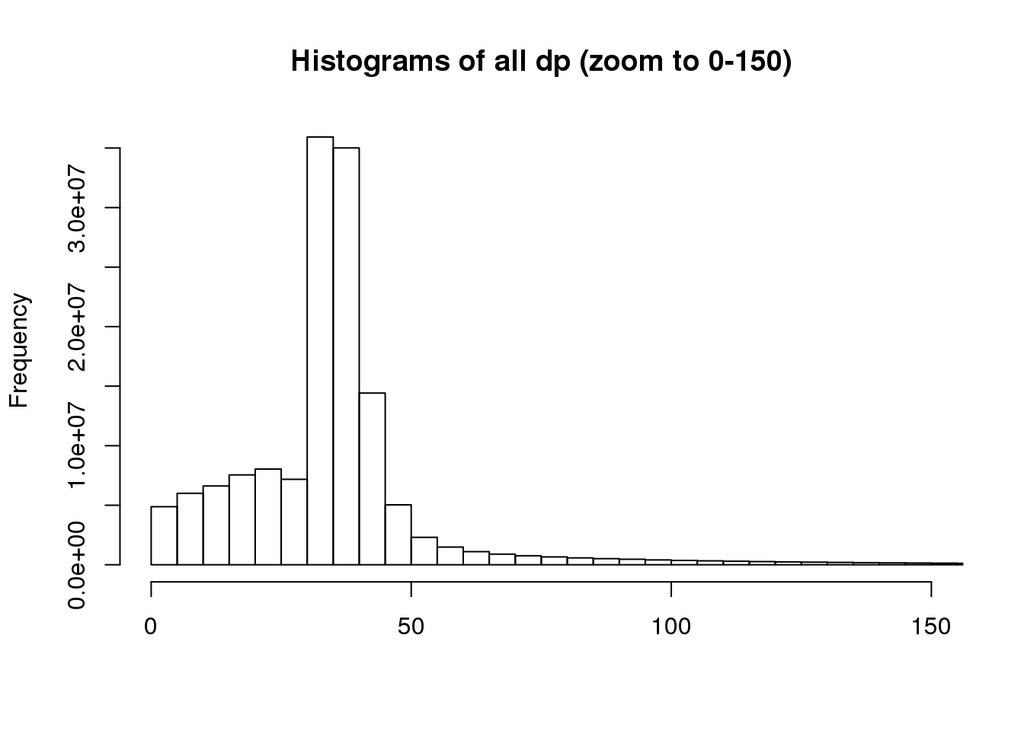

```r
hist(dp.mx, breaks=500, xlim=c(0,150), main="Histograms of all dp (zoom to 0-150)", xlab=NULL)
```

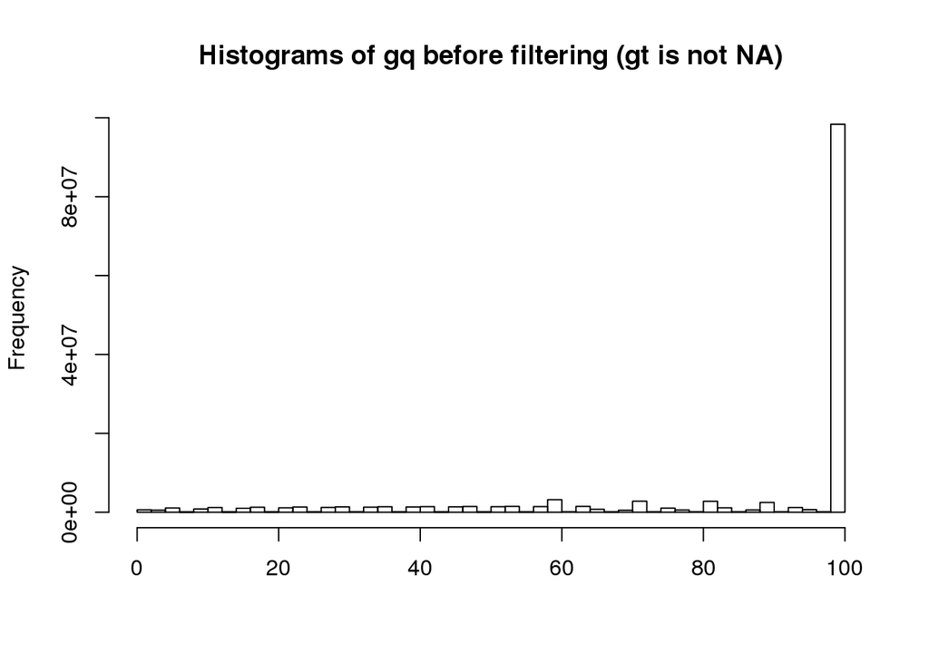

```r
# Histograms of gq and dp in retained genotypes
hist(gq.mx[!is.na(gt.mx)], breaks=50, main="Histograms of gq before filtering (gt is not NA)", xlab=NULL)
```

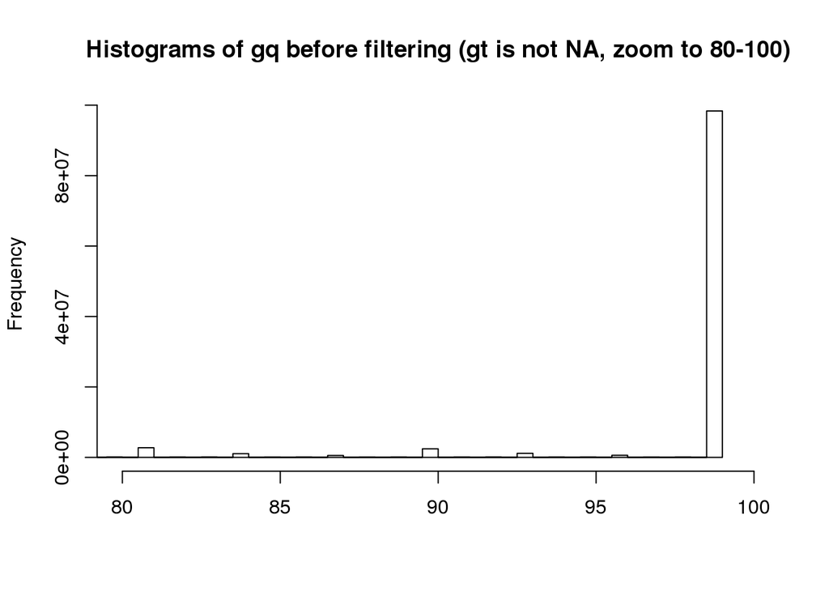

```r
hist(gq.mx[!is.na(gt.mx)], breaks=250, xlim=c(80,100), main="Histograms of gq before filtering (gt is not NA, zoom to 80-100)", xlab=NULL)
```

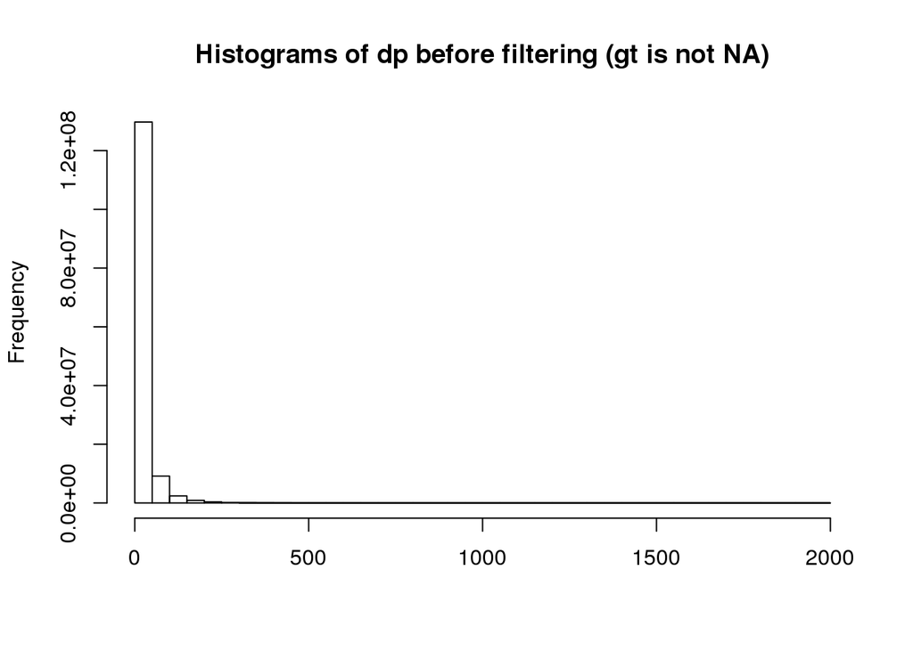

```r
hist(dp.mx[!is.na(gt.mx)], breaks=50, main="Histograms of dp before filtering (gt is not NA)", xlab=NULL)
```

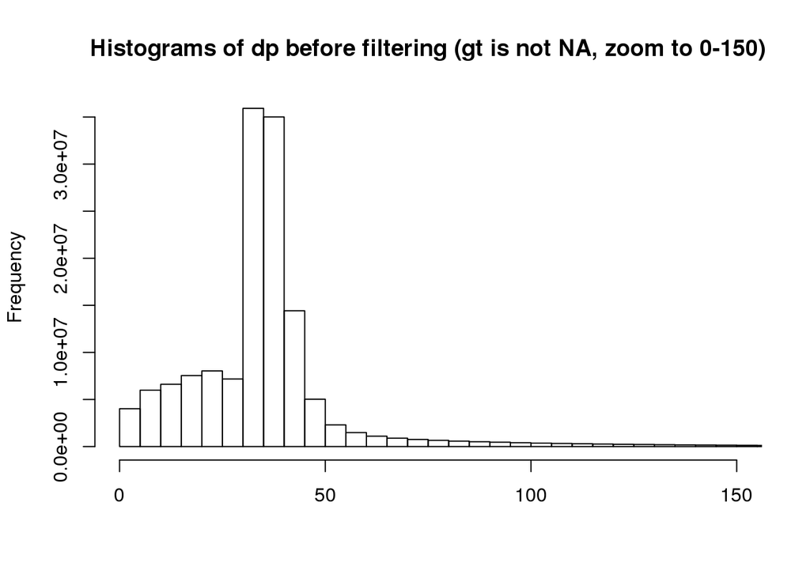

```r
hist(dp.mx[!is.na(gt.mx)], breaks=500, xlim=c(0,150), main="Histograms of dp before filtering (gt is not NA, zoom to 0-150)", xlab=NULL)
```

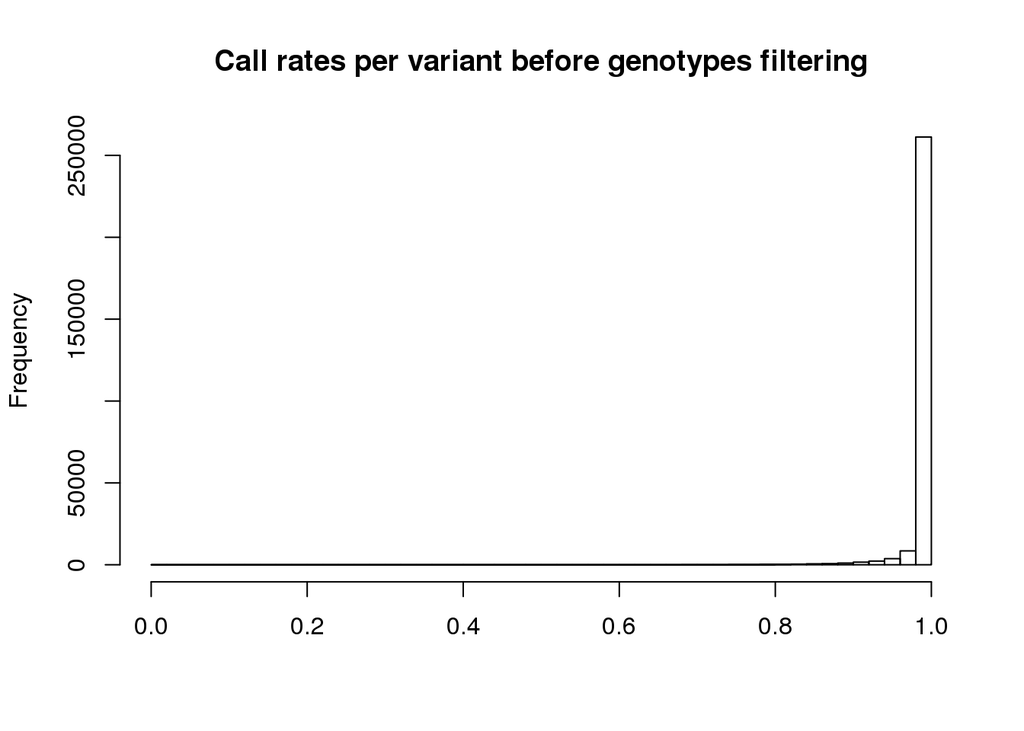

```r
# Call rates per variant before genotype filtering
x <- ncol(gt.mx)
y <- apply(gt.mx,1,function(z){1-sum(is.na(z))/x})
hist(y, breaks=50, xlab=NULL, main="Call rates per variant before genotypes filtering")
```

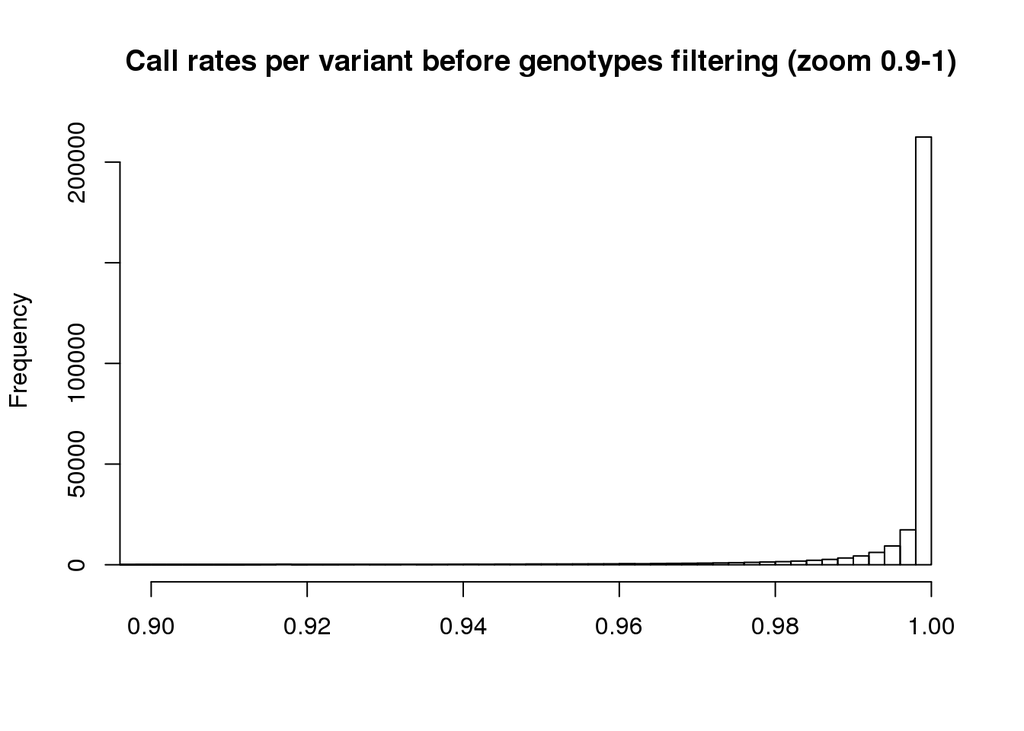

```r
hist(y, breaks=500, xlim=c(0.9,1), xlab=NULL, main="Call rates per variant before genotypes filtering (zoom 0.9-1)")
```

```r
rm(x,y)
```

# filter_by_gq

```r
sum(gq.mx < min.gq, na.rm=TRUE)
```

```
## [1] 6632656
```

```r
sum(gq.mx < min.gq, na.rm=TRUE)/sum(!is.na(gq.mx))
```

```
## [1] 0.04643165
```

```r
NA -> gt.mx[ gq.mx < min.gq ]
rm(min.gq)

# num of NAs after filter
sum(is.na(gt.mx))/(dim(gt.mx)[1]*dim(gt.mx)[2]) # ~5%
```

```
## [1] 0.05248519
```

# filter_by_dp

```r
sum(dp.mx < min.dp, na.rm=TRUE)
```

```
## [1] 9554763
```

```r
sum(dp.mx < min.dp, na.rm=TRUE)/sum(!is.na(gq.mx))
```

```
## [1] 0.06688774
```

```r
sum(dp.mx > max.dp, na.rm=TRUE)
```

```
## [1] 20720
```

```r
sum(dp.mx > max.dp, na.rm=TRUE)/sum(!is.na(gq.mx))
```

```
## [1] 0.0001450495
```

```r
NA -> gt.mx[ dp.mx < min.dp ]
NA -> gt.mx[ dp.mx > max.dp ]

rm(min.dp, max.dp)

# num of NAs after filter
sum(is.na(gt.mx))/(dim(gt.mx)[1]*dim(gt.mx)[2]) # ~7%
```

```
## [1] 0.07349478
```

# calculate_fractions_of_reads_with_minor_allele

```r
# Sum of ref and alt
sum.mx <- ref.mx + alt.mx

dim(sum.mx)
```

```
## [1] 280782    512
```

```r
sum.mx[1:15,1:5]
```

```
##              P1_A01.AD P1_A02.AD P1_A03.AD P1_A04.AD P1_A05.AD
## var000000060        47       151        34        53        41
## var000000107        18         0         1        21         5
## var000000109         3         0         2        17         3
## var000000117         8         7         4        10         2
## var000000118        13         8         7        28         5
## var000000119        12         6         6        25         4
## var000000120         7         1         1        17         4
## var000000124        15         4         4        29         9
## var000000140        19         8        12        22        10
## var000000157        35        20        28        40        36
## var000000158        37        24        31        40        36
## var000000159        20        18        12        37        16
## var000000163        27         5         8        51         7
## var000000169        33        10        19        37        13
## var000000170        32         6        16        37        19
```

```r
# Subtract alt from ref
ref.sub.alt <- ref.mx - alt.mx

dim(ref.sub.alt)
```

```
## [1] 280782    512
```

```r
ref.sub.alt[1:15,1:5]
```

```
##              P1_A01.AD P1_A02.AD P1_A03.AD P1_A04.AD P1_A05.AD
## var000000060        47       115        34        53        41
## var000000107        18         0         1        21         5
## var000000109         3         0         2        17         3
## var000000117         8         7         4        10         2
## var000000118        13         8         7        28         5
## var000000119        12         6         6        25         4
## var000000120         7         1         1        17         4
## var000000124        15         4         4        29         9
## var000000140        19         8        12        22        10
## var000000157        35        20        28        40        36
## var000000158        37        24        31        40        36
## var000000159        20        18        12        37        16
## var000000163       -27         1        -6        11        -7
## var000000169        33        10        19        37        13
## var000000170        32         6        16        37        19
```

```r
# Count reads with minor allele (crma)
crma.mx <- ref.sub.alt
crma.mx[ref.sub.alt == 0] <- ref.mx[ref.sub.alt == 0] # use any (e.g. ref) if no difference
crma.mx[ref.sub.alt < 0] <- ref.mx[ref.sub.alt < 0] # use ref, if itis smaller
crma.mx[ref.sub.alt > 0] <- alt.mx[ref.sub.alt > 0] # use alt, if it is smaller

dim(crma.mx)
```

```
## [1] 280782    512
```

```r
crma.mx[1:15,1:5]
```

```
##              P1_A01.AD P1_A02.AD P1_A03.AD P1_A04.AD P1_A05.AD
## var000000060         0        18         0         0         0
## var000000107         0         0         0         0         0
## var000000109         0         0         0         0         0
## var000000117         0         0         0         0         0
## var000000118         0         0         0         0         0
## var000000119         0         0         0         0         0
## var000000120         0         0         0         0         0
## var000000124         0         0         0         0         0
## var000000140         0         0         0         0         0
## var000000157         0         0         0         0         0
## var000000158         0         0         0         0         0
## var000000159         0         0         0         0         0
## var000000163         0         2         1        20         0
## var000000169         0         0         0         0         0
## var000000170         0         0         0         0         0
```

```r
ref.mx[1:15,1:5]
```

```
##              P1_A01.AD P1_A02.AD P1_A03.AD P1_A04.AD P1_A05.AD
## var000000060        47       133        34        53        41
## var000000107        18         0         1        21         5
## var000000109         3         0         2        17         3
## var000000117         8         7         4        10         2
## var000000118        13         8         7        28         5
## var000000119        12         6         6        25         4
## var000000120         7         1         1        17         4
## var000000124        15         4         4        29         9
## var000000140        19         8        12        22        10
## var000000157        35        20        28        40        36
## var000000158        37        24        31        40        36
## var000000159        20        18        12        37        16
## var000000163         0         3         1        31         0
## var000000169        33        10        19        37        13
## var000000170        32         6        16        37        19
```

```r
alt.mx[1:15,1:5]
```

```
##              P1_A01.AD P1_A02.AD P1_A03.AD P1_A04.AD P1_A05.AD
## var000000060         0        18         0         0         0
## var000000107         0         0         0         0         0
## var000000109         0         0         0         0         0
## var000000117         0         0         0         0         0
## var000000118         0         0         0         0         0
## var000000119         0         0         0         0         0
## var000000120         0         0         0         0         0
## var000000124         0         0         0         0         0
## var000000140         0         0         0         0         0
## var000000157         0         0         0         0         0
## var000000158         0         0         0         0         0
## var000000159         0         0         0         0         0
## var000000163        27         2         7        20         7
## var000000169         0         0         0         0         0
## var000000170         0         0         0         0         0
```

```r
rm(ref.sub.alt)

# Calculate fractions of reads with minor allele (frma)
frma.mx <- crma.mx/sum.mx

dim(frma.mx)
```

```
## [1] 280782    512
```

```r
frma.mx[1:15,1:5]
```

```
##              P1_A01.AD P1_A02.AD P1_A03.AD P1_A04.AD P1_A05.AD
## var000000060         0 0.1192053     0.000 0.0000000         0
## var000000107         0       NaN     0.000 0.0000000         0
## var000000109         0       NaN     0.000 0.0000000         0
## var000000117         0 0.0000000     0.000 0.0000000         0
## var000000118         0 0.0000000     0.000 0.0000000         0
## var000000119         0 0.0000000     0.000 0.0000000         0
## var000000120         0 0.0000000     0.000 0.0000000         0
## var000000124         0 0.0000000     0.000 0.0000000         0
## var000000140         0 0.0000000     0.000 0.0000000         0
## var000000157         0 0.0000000     0.000 0.0000000         0
## var000000158         0 0.0000000     0.000 0.0000000         0
## var000000159         0 0.0000000     0.000 0.0000000         0
## var000000163         0 0.4000000     0.125 0.3921569         0
## var000000169         0 0.0000000     0.000 0.0000000         0
## var000000170         0 0.0000000     0.000 0.0000000         0
```

```r
crma.mx[1:15,1:5]
```

```
##              P1_A01.AD P1_A02.AD P1_A03.AD P1_A04.AD P1_A05.AD
## var000000060         0        18         0         0         0
## var000000107         0         0         0         0         0
## var000000109         0         0         0         0         0
## var000000117         0         0         0         0         0
## var000000118         0         0         0         0         0
## var000000119         0         0         0         0         0
## var000000120         0         0         0         0         0
## var000000124         0         0         0         0         0
## var000000140         0         0         0         0         0
## var000000157         0         0         0         0         0
## var000000158         0         0         0         0         0
## var000000159         0         0         0         0         0
## var000000163         0         2         1        20         0
## var000000169         0         0         0         0         0
## var000000170         0         0         0         0         0
```

```r
sum.mx[1:15,1:5]
```

```
##              P1_A01.AD P1_A02.AD P1_A03.AD P1_A04.AD P1_A05.AD
## var000000060        47       151        34        53        41
## var000000107        18         0         1        21         5
## var000000109         3         0         2        17         3
## var000000117         8         7         4        10         2
## var000000118        13         8         7        28         5
## var000000119        12         6         6        25         4
## var000000120         7         1         1        17         4
## var000000124        15         4         4        29         9
## var000000140        19         8        12        22        10
## var000000157        35        20        28        40        36
## var000000158        37        24        31        40        36
## var000000159        20        18        12        37        16
## var000000163        27         5         8        51         7
## var000000169        33        10        19        37        13
## var000000170        32         6        16        37        19
```

```r
# These checks are identical
# NA is any Non Available data (e.g. something was missed)
# NaN = Not a Number (e.g. Infinity, when genotypes with zero sum of ref + alt ...)?
sum(is.na(frma.mx))
```

```
## [1] 767666
```

```r
sum(is.nan(frma.mx))
```

```
## [1] 767666
```

```r
sum(!is.finite(frma.mx))
```

```
## [1] 767666
```

```r
rm(crma.mx, sum.mx)
```

# filter_by_fraction_of_reads_with_minor_allele

```r
# num of NAs before filters
sum(is.na(gt.mx))
```

```
## [1] 10565638
```

```r
sum(is.na(gt.mx))/(dim(gt.mx)[1]*dim(gt.mx)[2]) # ~7%
```

```
## [1] 0.07349478
```

```r
# Filter out genotype calls with uncertain maf.
# This picks a very small number of genotypes (20 of 10M), which somehow had been
# called and passed DP and GQ filters despite both Ref and Alt being Zero ...
# It's scary to have such genotype calls ...
NA -> gt.mx[ !is.finite(frma.mx) ]

# num of NAs after filter
sum(is.na(gt.mx))
```

```
## [1] 10565658
```

```r
sum(is.na(gt.mx))/(dim(gt.mx)[1]*dim(gt.mx)[2]) # ~7%
```

```
## [1] 0.07349492
```

```r
# Filter homozigous genotype calls (i.e. coded 0 or 2)
# that have too high minor allele reads fraction
NA -> gt.mx[ gt.mx != 1 & frma.mx > max.frma.hom ]
rm(max.frma.hom)

# num of NAs after filter
sum(is.na(gt.mx))
```

```
## [1] 10679107
```

```r
sum(is.na(gt.mx))/(dim(gt.mx)[1]*dim(gt.mx)[2]) # ~7%
```

```
## [1] 0.07428407
```

```r
# Filter heterozigous genotype calls (i.e. coded 1)
# that have too low minor allele reads fraction
NA -> gt.mx[ gt.mx == 1 & frma.mx < min.frma.het ]
rm(frma.mx, min.frma.het)

# num of NAs after filter
sum(is.na(gt.mx))
```

```
## [1] 12178387
```

```r
sum(is.na(gt.mx))/(dim(gt.mx)[1]*dim(gt.mx)[2]) # ~8%
```

```
## [1] 0.08471309
```

# filter_variants_by_call_rate

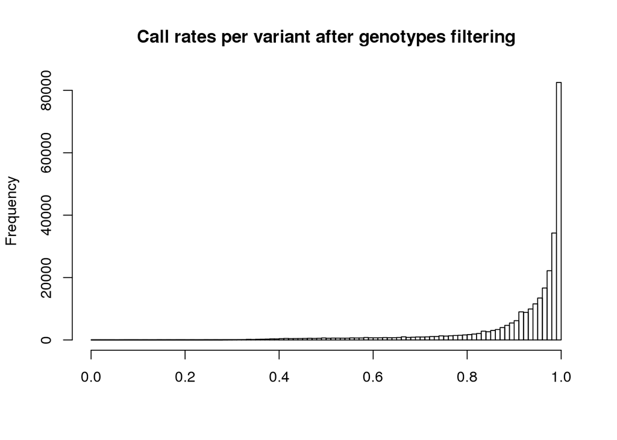

```r
# Call rates per variant before after genotypes filtering
x <- ncol(gt.mx)
y <- apply(gt.mx, 1, function(z){1-sum(is.na(z))/x})
hist(y, breaks=100, xlab=NULL, main="Call rates per variant after genotypes filtering")
```

```r
# Set filter and estimate the proportion of variants to remove
var.retained <- y >= min.call.rate
sum(var.retained)
```

```
## [1] 246168
```

```r
1-sum(var.retained)/nrow(gt.mx)
```

```
## [1] 0.1232771
```

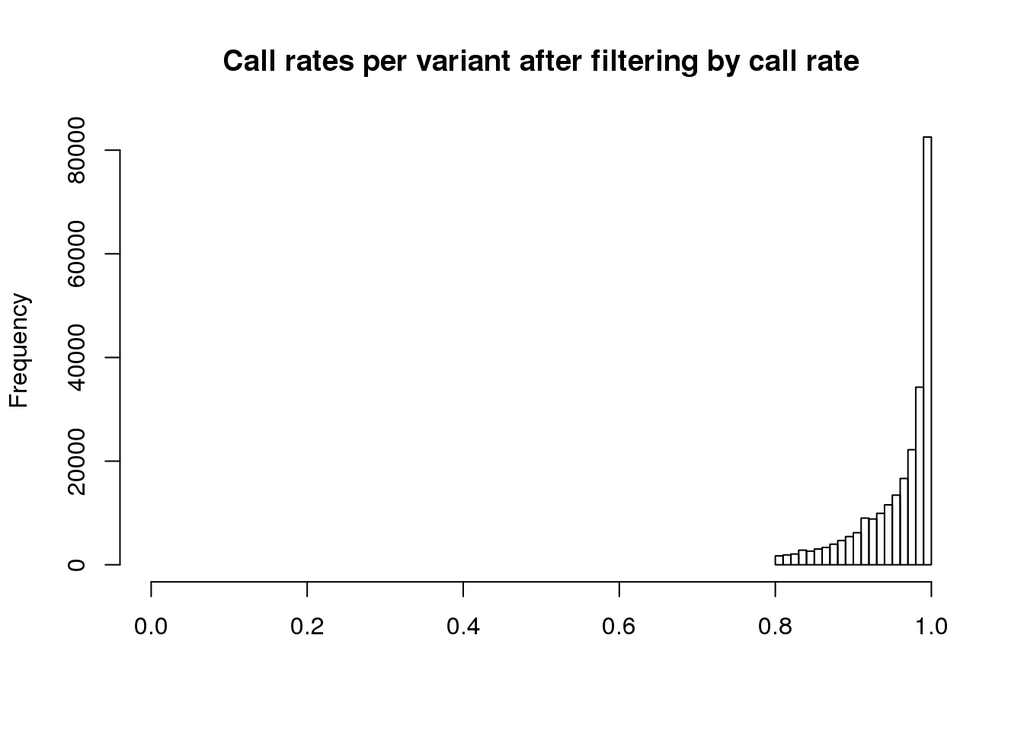

```r
rm(x,y,min.call.rate)

# Remove variants with loaw call rates
gt.mx <- gt.mx[ var.retained, ]
gq.mx <- gq.mx[ var.retained, ]
dp.mx <- dp.mx[ var.retained, ]
alt.mx <- alt.mx[ var.retained, ]
ref.mx <- ref.mx[ var.retained, ]
vv.df <- vv.pf.df[ var.retained, ]
rm(var.retained, vv.pf.df)

# Call rates per variant after filtering by call rate
x <- ncol(gt.mx)
y <- apply(gt.mx, 1, function(z){1-sum(is.na(z))/x})
hist(y, breaks=20, xlab=NULL, xlim=c(0,1), main="Call rates per variant after filtering by call rate")
```

```r
rm(x,y)
```

# histograms_after_filtering

```r
# Total num of NAs after genotypes filtering and removal of variants with low call rate
sum(is.na(gt.mx))/(dim(gt.mx)[1]*dim(gt.mx)[2]) # ~4%
```

```
## [1] 0.04205625
```

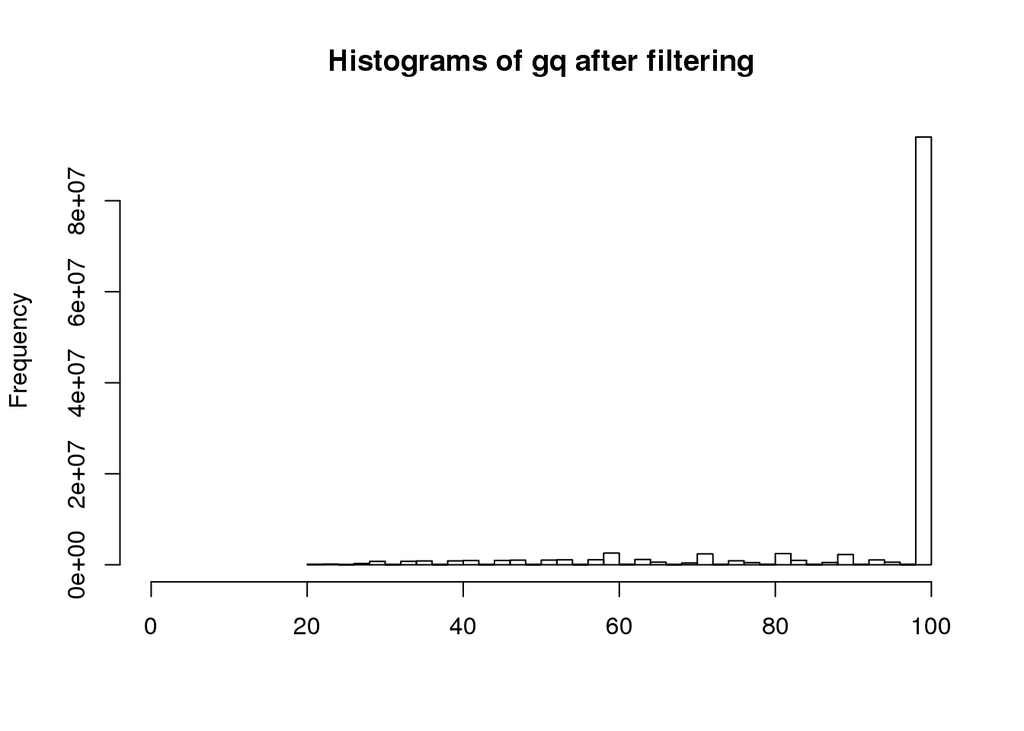

```r
# Histograms of gq and dp after filtering
hist(gq.mx[!is.na(gt.mx)], breaks=50, xlim=c(0,100), main="Histograms of gq after filtering", xlab=NULL)
```

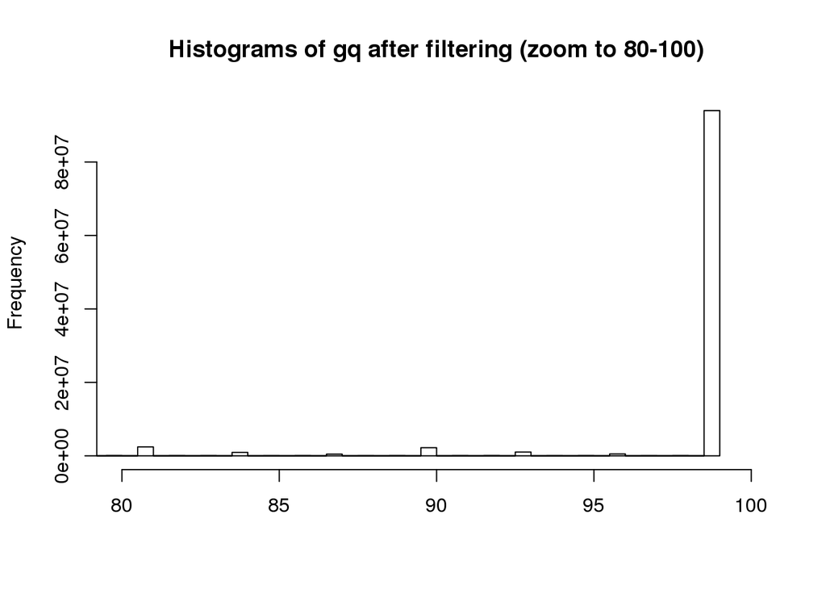

```r
hist(gq.mx[!is.na(gt.mx)], breaks=200, xlim=c(80,100), main="Histograms of gq after filtering (zoom to 80-100)", xlab=NULL)
```

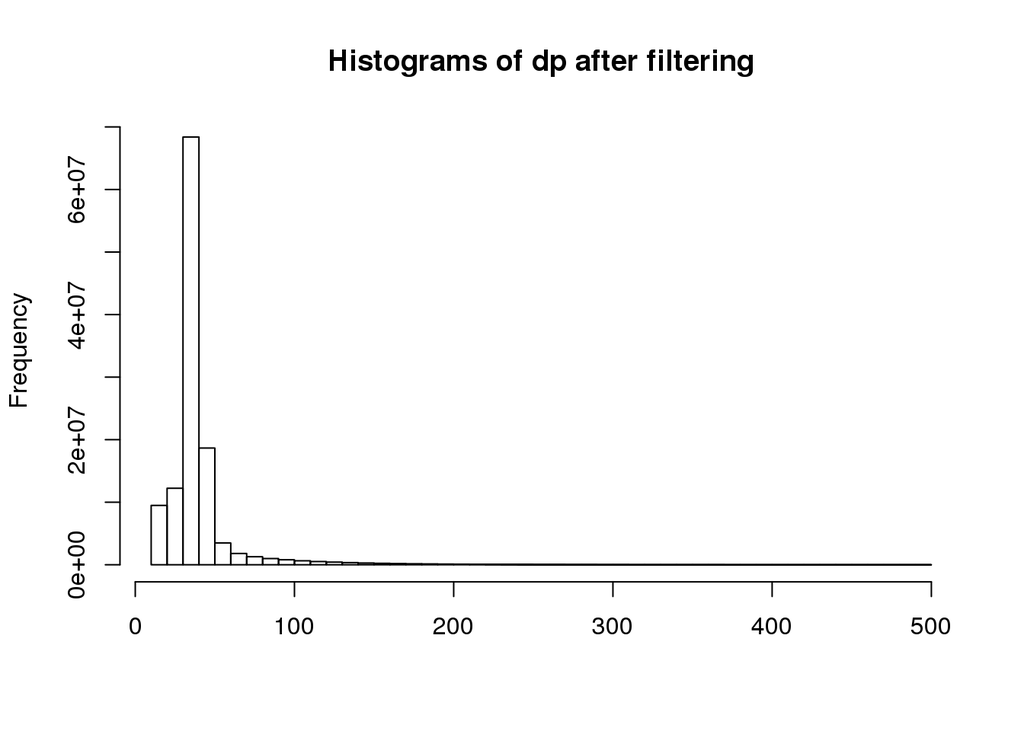

```r
hist(dp.mx[!is.na(gt.mx)], breaks=50, main="Histograms of dp after filtering", xlab=NULL)
```

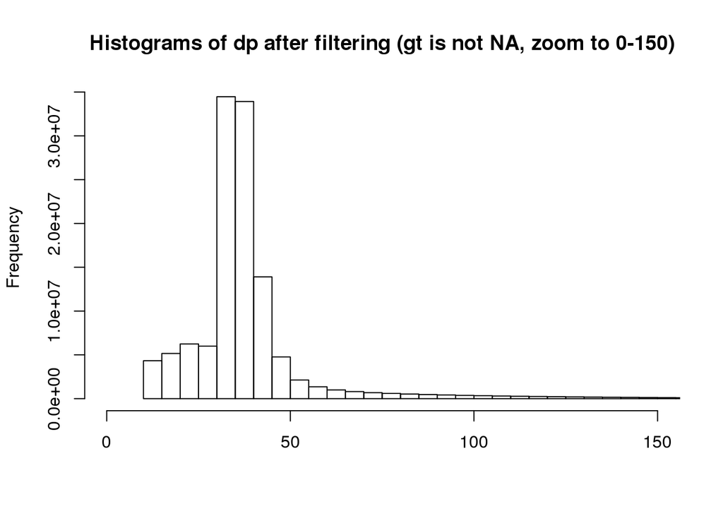

```r
hist(dp.mx[!is.na(gt.mx)], breaks=150, xlim=c(0,150), main="Histograms of dp after filtering (gt is not NA, zoom to 0-150)", xlab=NULL)
```

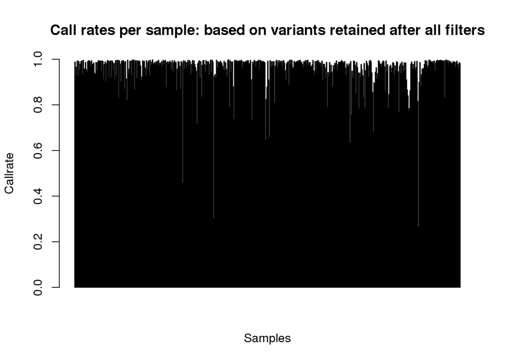

```r
# Call rates per sample: based on variants retained after all filters
x <- nrow(gt.mx)
y <- apply(gt.mx, 2, function(z){1-sum(is.na(z))/x})
barplot(y, ylab="Callrate", ylim=c(0,1), xlab="Samples", xaxt="n",
  main="Call rates per sample: based on variants retained after all filters")
```

```r
rm(x,y)
```

# save_data

```r
save.image(file="data/s03_filter_genotypes_feb2016.RData")
```

# final_section

```r
ls()
```

```
## [1] "alt.mx"          "covar.df"        "demographics.df" "dp.mx"
## [5] "gq.mx"           "gt.mx"           "ref.mx"          "samples.df"
## [9] "vv.df"
```

```r
Sys.time()
```

```
## [1] "2016-05-13 15:46:31 BST"
```